# Querypoint Debugger lastChange Demo Walkthru

## The Querypoint Panel, First Look

Click the Querypoint Tab to Open the Querypoint Panel. The first time you open the panel, a file selection dialog comes up. To select files later, use `control + o`

Select demo.js by clicking on it, typing it in to the filter, or using arrow keys plus enter.

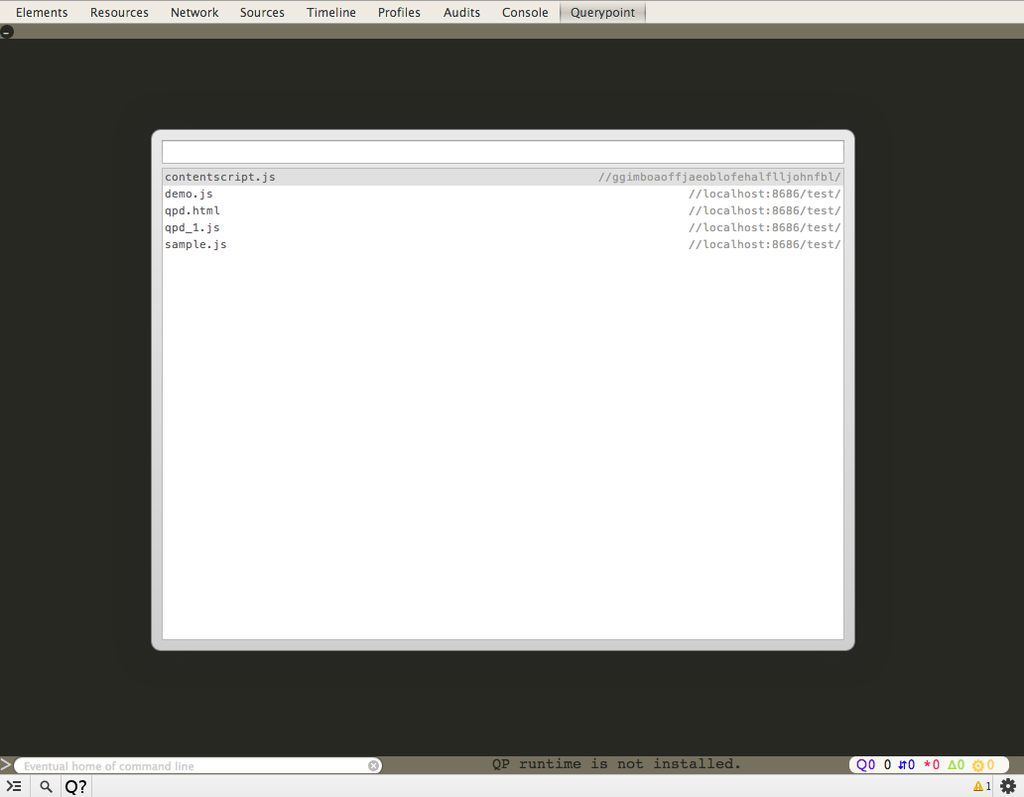

## Viewing source file demo.js

The source for demo.js appears on the right hand side; mouse over the source to see the left-hand-side token information change.

Find the function `updateButton()` and click on `prop` in `obj.prop`

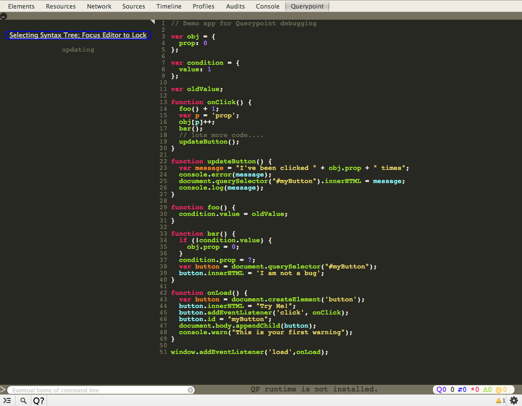

## Selecting `lastChange` for an object property

Now the mouse-over action stops and the left-hand-side panel locks on `obj.prop`

Click on the `lastChange` button for `obj.prop`

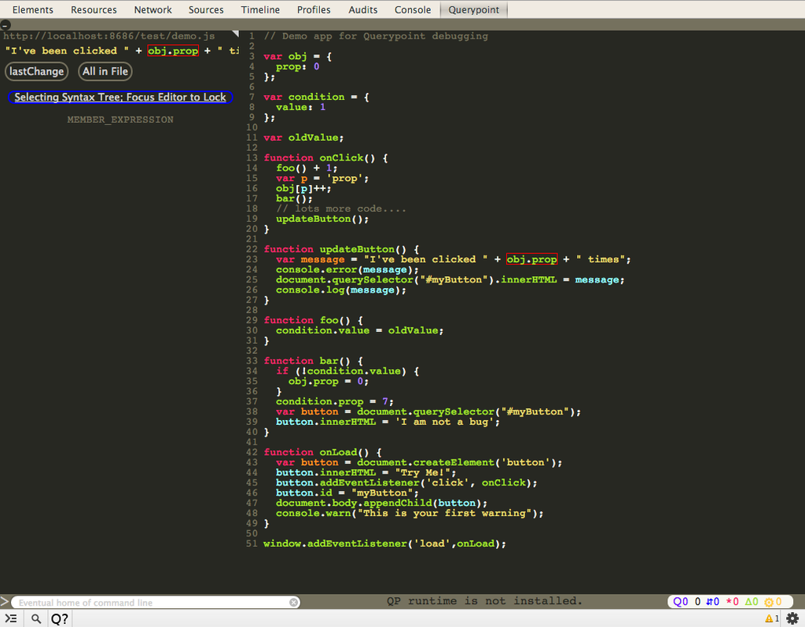

## Execising the Bug

The Querypoint is loaded into the page and the left-hand-side panel shows that the query is ready.

Click on the `try me` button in the Web page we are debugging

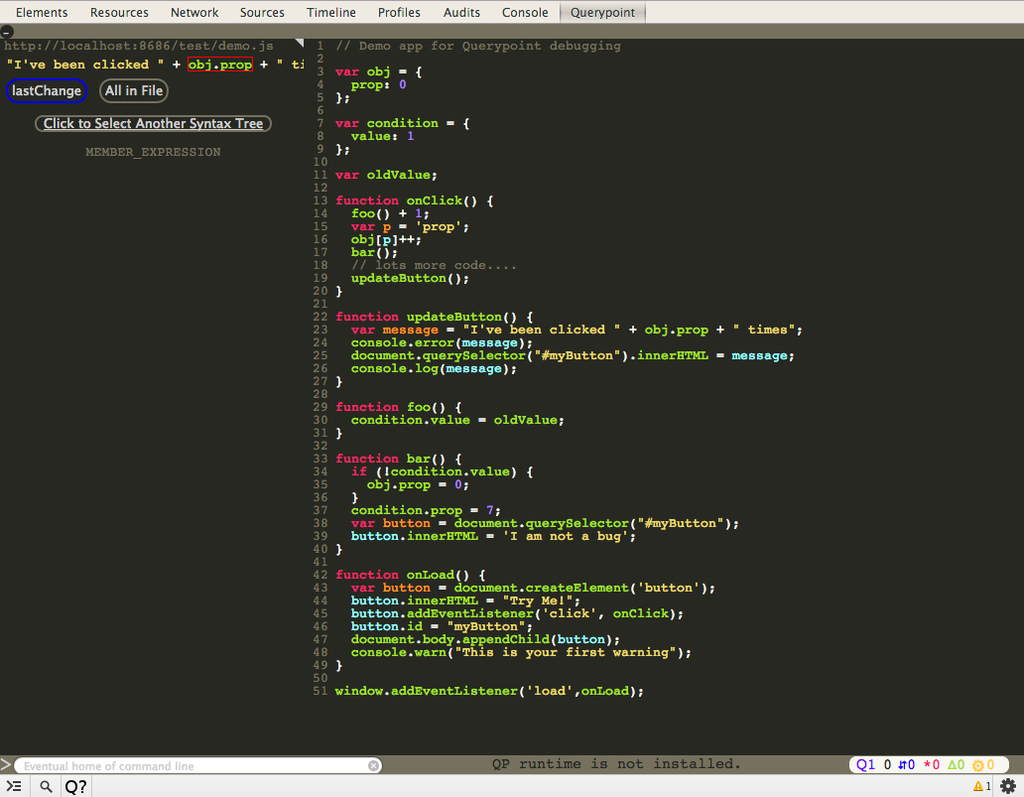

## `lastChange` Result

The trace results for the `lastChange` appear as soon as the click event turn ends. The delta (𝚫) icons indicate last change results with the load number, turn number and file-activation counts preceding the value.

Click on the 𝚫 button, you should see the location of the lastChange highlighted in the page

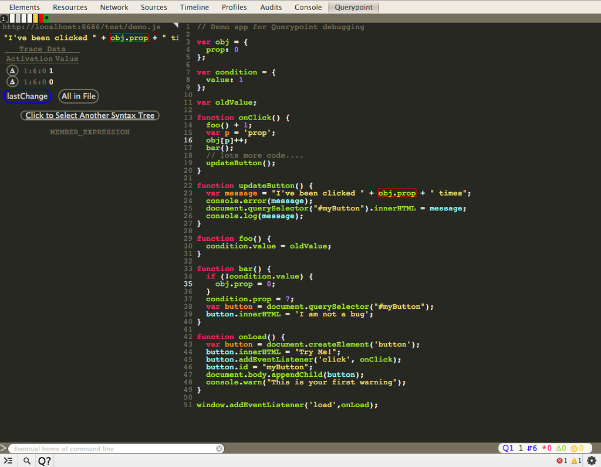